# HW04 Part 1: Complete Chapter 3

Cody Grainger

13 July 2020

## Chapter 3

- Change “your name” in the YAML header above to your name.

### Section 3.1

Load the tidyverse packages. I’ve entered the first code chunk for you. **You must enter all subsequent code chunks and run the code.**

```r
library("tidyverse")
```

If you get an error, then you did not install the `tidyverse` package like you were supposed to in the previous assignment. Go back to that assignment and complete that step. (This should not be the case, though.)

### Section 3.2: First steps

Enter your code chunks for Section 3.2 here.

Get in the habit of entering a brief description of what each chunk of code does. Enter this above the chunk, like I did in Section 3.1.

# 3.3.2 the ‘mpg’ data frame

- Displays a data frame of the data set ‘mpg’.

```r
ggplot2::mpg
```

| manufacturer | model | displ | year | cyl | trans | drv | cty | hwy | fl | class |
| --- | --- | --- | --- | --- | --- | --- | --- | --- | --- | --- |
| audi | a4 | 1.8 | 1999 | 4 | auto(l5) | f | 18 | 29 | p | compact |
| audi | a4 | 1.8 | 1999 | 4 | manual(m5) | f | 21 | 29 | p | compact |
| audi | a4 | 2.0 | 2008 | 4 | manual(m6) | f | 20 | 31 | p | compact |
| audi | a4 | 2.0 | 2008 | 4 | auto(av) | f | 21 | 30 | p | compact |
| audi | a4 | 2.8 | 1999 | 6 | auto(l5) | f | 16 | 26 | p | compact |
| audi | a4 | 2.8 | 1999 | 6 | manual(m5) | f | 18 | 26 | p | compact |
| audi | a4 | 3.1 | 2008 | 6 | auto(av) | f | 18 | 27 | p | compact |
| audi | a4 quattro | 1.8 | 1999 | 4 | manual(m5) | 4 | 18 | 26 | p | compact |
| audi | a4 quattro | 1.8 | 1999 | 4 | auto(l5) | 4 | 16 | 25 | p | compact |
| audi | a4 quattro | 2.0 | 2008 | 4 | manual(m6) | 4 | 20 | 28 | p | compact |

[output cut: 224 more lines]

#### Section 3.2 Questions

Answer the questions *completely.* Some answers will require you to write code in a code chunk and also to type text before or after the chunk. Other answers will require only code or only text.

**1:** Run ggplot(data = mpg). What do you see?

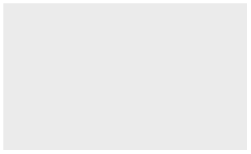

```r
ggplot(data = mpg)
```

After running the code I am left with a blank box

**2:** How many rows are in `mpg`? How many columns? **Hint:** Use the `dim()` function. Type `dim()` in the console to learn what `dim()` does.

‘dim()’ is used to retrieve the dimensions of an object such as our data frame. For data frames it will display the number of rows and columns.

```r
dim(mpg)
```

```
[1] 234  11
```

There are 234 rows and 11 columns in the mpg data frame.

**3:** What does the `drv` variable describe? Read the help for `?mpg` to find out.

?mpg returns a list describing the drv variable as the type of drive train the vehicle has (f=front, r=rear, 4=4wd)

**4:** Make a scatterplot of `hwy` vs `cyl`.

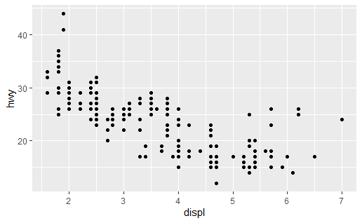

```r
ggplot(data=mpg) +
  geom_point(mapping=aes(x=displ, y=hwy))
```

A scatterplot with additional code to plot ‘hwy’ and ‘displ’ from the ‘mpg’ data

**5:** What happens if you make a scatterplot of `class` vs `drv`? Why is the plot not useful?

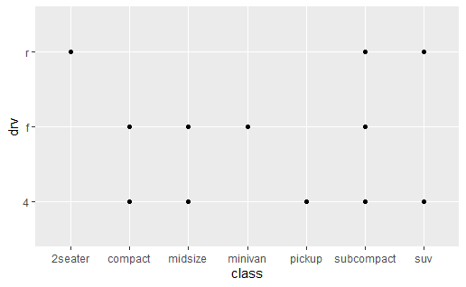

```r
ggplot(data=mpg) +
  geom_point(mapping=aes(x=class, y=drv))
```

The scatterplot is rather unorganized and not very useful as it does not show any meaningful trend

### Section 3.3: Aesthetic mappings

#Examples from the text

Changing the aesthetic of objects within plots.

in the example below I color the points according to class

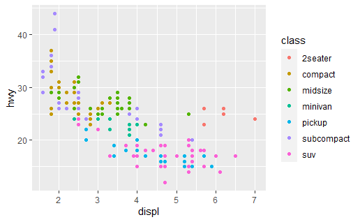

```r
ggplot(data=mpg) +
  geom_point(mapping = aes(x=displ,y=hwy,color=class))
```

Aesthetic changes are not just limited to color. Below is the same demonstaration as above but using size instead of color

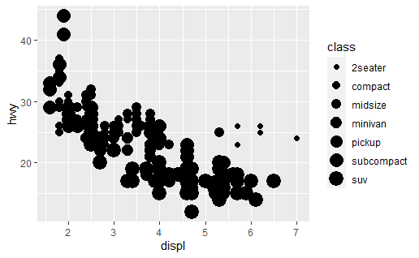

```r
ggplot(data=mpg) +
  geom_point(mapping = aes(x=displ,y=hwy,size=class))
```

two more examples using shape and aplpha changes for objects within a plot. changes in objects are again based off of car class

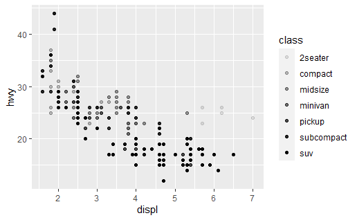

```r
ggplot(data=mpg) +
  geom_point(mapping = aes(x=displ,y=hwy,alpha=class))
```

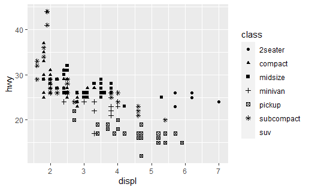

```r
ggplot(data=mpg) +
  geom_point(mapping = aes(x=displ,y=hwy,shape=class))
```

Manual setting of the aesthetic rather than using a variable

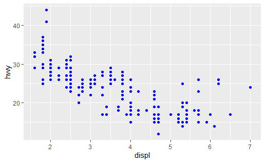

```r
ggplot(data=mpg) +
  geom_point(mapping = aes(x=displ,y=hwy),color="blue")
```

#### Section 3.3 questions

**1:** What’s gone wrong with this code? Why are the points not blue?

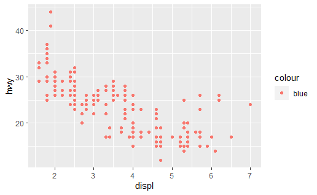

```r
ggplot(data=mpg) +
  geom_point(mapping = aes(x=displ,y=hwy,color="blue"))
```

The above code does not return blue colored dots because aes() associates an aesthetic with a variable and “blue” is not a variable in the data. color=“blue” must be used as part of the geometry function.

**2:** Which variables in `mpg` are categorical? Which variables are continuous? (*Hint:* type `?mpg` to read the documentation for the dataset). How can you see this information when you run mpg?

variables manufacturer, model, displ, year, cyl, trans, drv, fl, and class categorizes the data while variables cty and hwy are continuous variables as they describe a rate that varies with the categories

**3:** Map a continuous variable to color, size, and shape. How do these aesthetics behave differently for categorical vs. continuous variables? **Note:** You need several code chunks here to answer this question.

using aes() to map color to categoricial and continuous variables

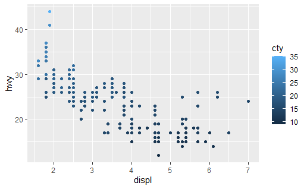

```r
#first the continuous is plotted. 'cty'
ggplot(data=mpg) +
  geom_point(mapping = aes(x=displ,y=hwy,color=cty))
```

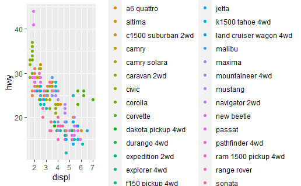

```r
#the categorical variable 'model'
ggplot(data=mpg) +
  geom_point(mapping = aes(x=displ,y=hwy,color=model))
```

aes() to apply size aesthetic to continuous and categorical variables.

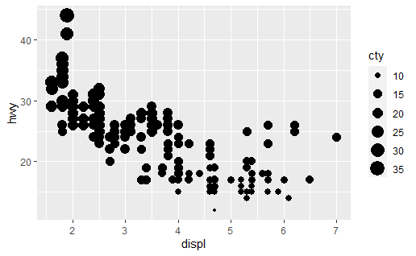

```r
#using the same variable 'cty'
ggplot(data=mpg) +
  geom_point(mapping = aes(x=displ,y=hwy,size=cty))
```

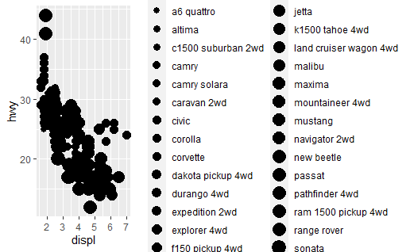

```r
#and again the categorical variable 'model'
ggplot(data=mpg) +
  geom_point(mapping = aes(x=displ,y=hwy,size=model))
```

Similarly to above using the cty variable to set the size aesthetic gives a generalization about how cty varies with hwy and displ. mapping size to model makes the plot unreadable

```r
#variable 'cty' again. 'cty'
ggplot(data=mpg) +
  geom_point(mapping = aes(x=displ,y=hwy,shape=cty))
```

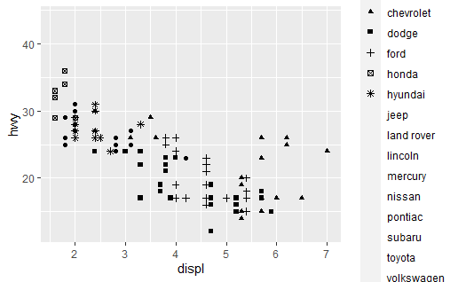

```r
#the categorical variable 'manufacturer' this time
ggplot(data=mpg) +
  geom_point(mapping = aes(x=displ,y=hwy,shape=manufacturer))
```

mapping shape to the continuous variable cty does not work. Mapping shape to manufacturer is not very useful as just looking at the plot it would be impossible to tell what the model of car is as they are all plotted with the same sybol per manufacturer and many manufacturers are not listed and there can only be a max of 6 discrete values

**4:** What happens if you map the same variable to multiple aesthetics?

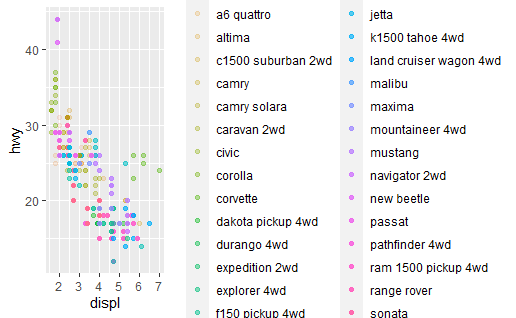

```r
ggplot(data=mpg) +
  geom_point(mapping = aes(x=displ,y=hwy,color=model,alpha=model))
```

Mapping both color and alpha to model just combines the effects but in this particular example it doesnt help define which points on the plot are which specific models

**5:** What does the stroke aesthetic do? What shapes does it work with? (*Hint:* use `?geom_point`)

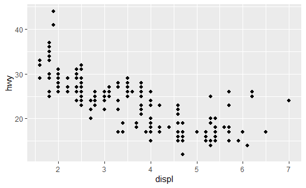

```r
ggplot(data=mpg) +
  geom_point(mapping = aes(x=displ,y=hwy),stroke = 1)
```

Stroke affects shapes with borders by changing border size

**6:** What happens if you map an aesthetic to something other than a variable name, like `aes(colour = displ < 5)`?

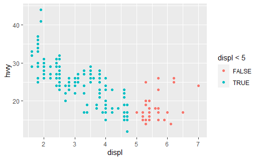

```r
ggplot(data=mpg) +
  geom_point(mapping = aes(x=displ,y=hwy,color=displ < 5))
```

When running the above code all objects with a displ value<5 are marked TRUE and all >= 5 are marked FALSE

### Section 3.5: Facets

Using facets to create subplots of the data ‘mpg’ facet_wrap()is not used within geom_point. the subplots will be divided by class of vehicle

```r
ggplot(data=mpg) +
```

[output not shown]

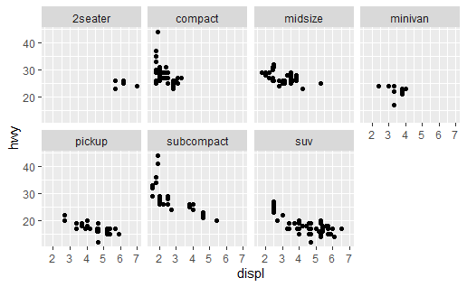

```r
  geom_point(mapping=aes(x=displ, y=hwy))+
  facet_wrap(~class,nrow=2)
```

Below is another facet that creates subplots based on two varibles. nrow is not needed for this and facet_grid is used instead of facet_wrap

```r
ggplot(data=mpg) +
```

[output not shown]

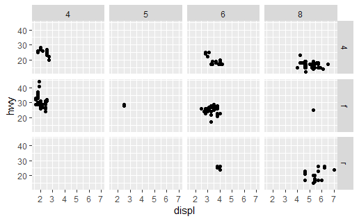

```r
  geom_point(mapping=aes(x=displ, y=hwy))+
  facet_grid(drv~cyl)
```

#### Section 3.5 questions

**1:** What happens if you facet on a continuous variable? **Note:** Write a prediction, then make and run your code chunk.

I predict the facet will create a subplot for each individual data point

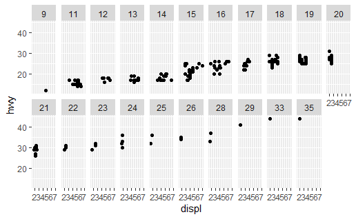

```r
ggplot(data=mpg) +
  geom_point(mapping=aes(x=displ, y=hwy))+
  facet_wrap(~cty,nrow=2)
```

**2:** What do the empty cells in plot with `facet_grid(drv ~ cyl)` mean? How do they relate to this plot?

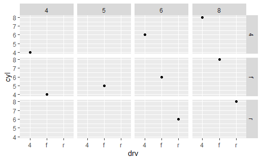

```r
ggplot(data = mpg) +
  geom_point(mapping = aes(x = drv, y = cyl)) +
  facet_grid(drv ~ cyl)
```

The three empty plots indicate that there are no data points for a vehicle that has 4wd and 5 cylinders and there are no data points for a vehicle that has rwd and either 4 or 5 cylinders

**3:** What plots does the following code make? What does `.` do?

```r
ggplot(data = mpg) +
```

[output not shown]

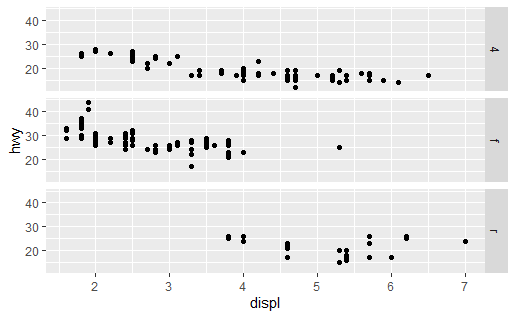

```r
  geom_point(mapping = aes(x = displ, y = hwy)) +
  facet_grid(drv ~ .)
```

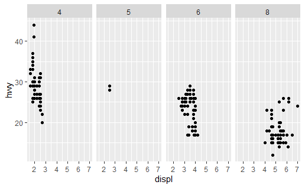

```r
ggplot(data = mpg) +
  geom_point(mapping = aes(x = displ, y = hwy)) +
  facet_grid(. ~ cyl)
```

The first equation does not facet with columns and the secon d does not facet with rows

**4:** Take the first faceted plot below. What are the advantages to using faceting instead of the colour aesthetic? What are the disadvantages? How might the balance change if you had a larger dataset?

```r
ggplot(data = mpg) +
```

[output not shown]

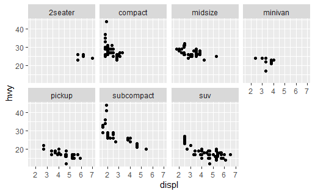

```r
  geom_point(mapping = aes(x = displ, y = hwy)) +
  facet_wrap(~ class, nrow = 2)
```

The advantage of a facet over changing the color aesthetic is that it helps to make data points more easily distinguishable for data with overlapping points. This advantage would probably be more noticeable with larger data sets as more points might have the possibility of overlapping.

**5:** Read `?facet_wrap`. What does `nrow` do? What does `ncol` do? What other options control the layout of the individual panels? Why doesn’t `facet_grid()` have nrow and ncol argument? nrow and ncol sets the number of rows and columns for each facet_wrap. these do not apply to facet_grid as the rows and columns are determined by the variables and cannot be manually set.

**6:** When using `facet_grid()` you should usually put the variable with more unique levels in the columns. Why?

Putting variables with more unique levels in the column has the potential to describe more about the data categorically as most computer displays are widescreen.

### Section 3.6: Geometric objects

Usuing two different visual plots to describe the same data by setting different geoms in ggplot2

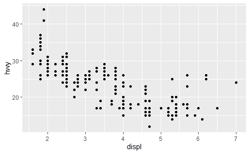

```r
#scatter
ggplot(data = mpg) +
  geom_point(mapping = aes(x = displ, y = hwy))
```

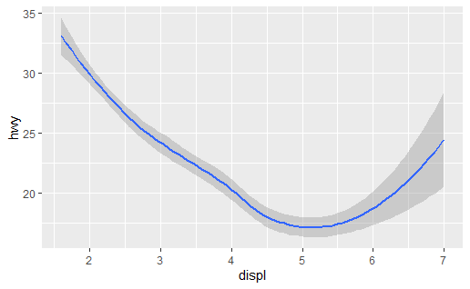

```r
#trend
ggplot(data = mpg) +
  geom_smooth(mapping = aes(x = displ, y = hwy))
```

Using the variable ‘drv’ to create multple smooth plot lines within one smooth plot based on the different drive train types

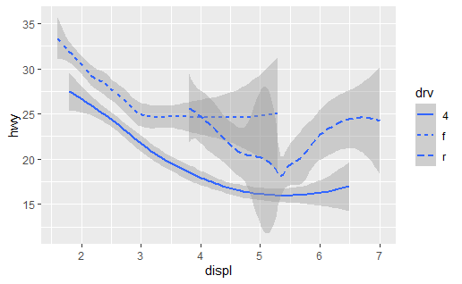

```r
ggplot(data = mpg) +
  geom_smooth(mapping = aes(x = displ, y = hwy, linetype = drv))
```

grouping and assigning color using variables to smooth geom plots

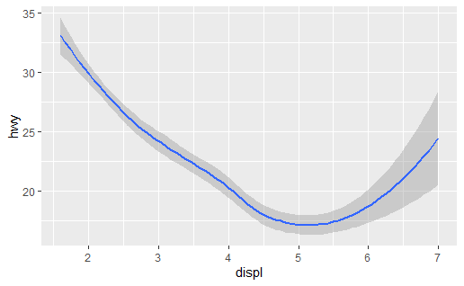

```r
ggplot(data=mpg)+
  geom_smooth(mapping=aes(x=displ,y=hwy))
```

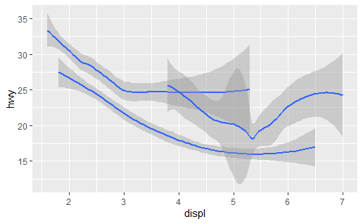

```r
ggplot(data=mpg)+
  geom_smooth(mapping=aes(x=displ,y=hwy,group=drv))
```

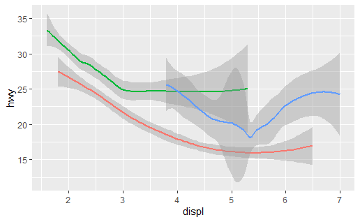

```r
ggplot(data=mpg)+
  geom_smooth(
    mapping = aes(x=displ,y=hwy,color=drv),
    show.legend=FALSE
  )
```

Placing multiple geoms within the same graph

```r
ggplot(data=mpg)+
```

[output not shown]

```r
  geom_point(mapping=aes(x=displ,y=hwy))+
  geom_smooth(mapping=aes(x=displ,y=hwy))
```

[output not shown]

combining two geom plots and arragning them by color according to a variable

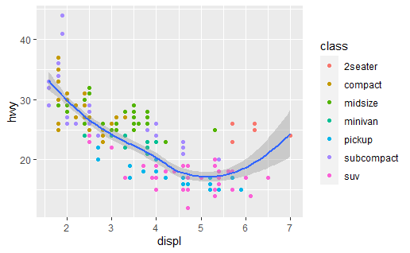

```r
ggplot(data = mpg, mapping = aes(x = displ, y = hwy)) +
  geom_point(mapping = aes(color = class)) +
  geom_smooth()
```

#### Section 3.6.1 Questions

**1:** What geom would you use to draw a line chart? A boxplot? A histogram? An area chart? **Note:** You will have to make some types of these charts in Part 2 of this assignment.

geom_line() is for line charts and geom_boxplot() is for boxplots

**2:** Run this code in your head and predict what the output will look like. Then, run the code in R and check your predictions.

I predict the below code will create the trend without the surrounding grey area (standard error im assuming)

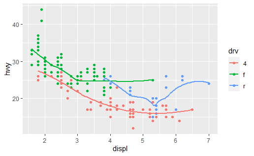

```r
ggplot(data = mpg, mapping = aes(x = displ, y = hwy, color = drv)) +
  geom_point() +
  geom_smooth(se = FALSE)
```

My prediction appears to be supported. The above plot does not inlude the grey areas

**3:** What does `show.legend = FALSE` do? What happens if you remove it? **Note:** Skip the “Why do you think I used it earlier in the chapter?” question.

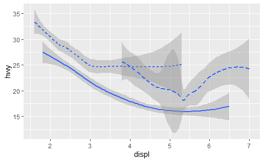

```r
ggplot(data = mpg) +
  geom_smooth(mapping = aes(x = displ, y = hwy, linetype = drv),show.legend=FALSE)
```

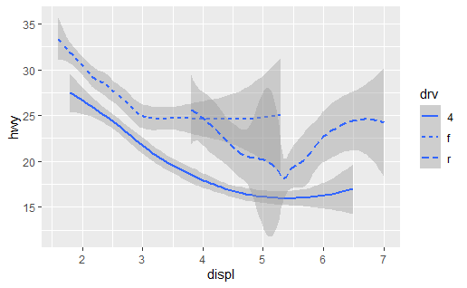

```r
ggplot(data = mpg) +
  geom_smooth(mapping = aes(x = displ, y = hwy, linetype = drv))
```

show.legend=FALSE removes the legend from the graph. removing it causes the legend to be shown.

**4:** What does the `se` argument to `geom_smooth()` do?

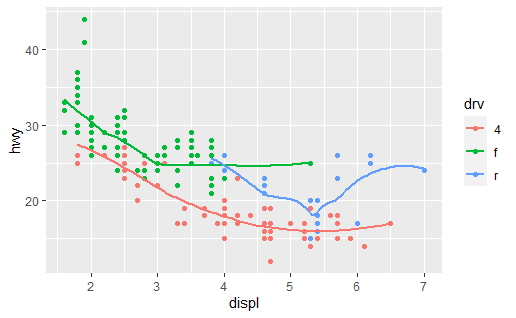

```r
ggplot(data = mpg, mapping = aes(x = displ, y = hwy, color = drv)) +
  geom_point() +
  geom_smooth(se = FALSE)
```

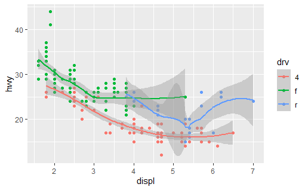

```r
ggplot(data = mpg, mapping = aes(x = displ, y = hwy, color = drv)) +
  geom_point() +
  geom_smooth(se = TRUE)
```

ctreating the two plots with the se values set opposite reveals that the se = FALSE removes the grey area and se = TRUE displays it.

**5:** Will these two graphs look different? Why/why not?

I believe these graphs will not look different as the geom functions are still aplied at the ggplot level and are not incorporated within aes()

```r
ggplot(data = mpg, mapping = aes(x = displ, y = hwy)) +
  geom_point() +
  geom_smooth()
```

[output not shown]

```r
ggplot() +
  geom_point(data = mpg, mapping = aes(x = displ, y = hwy)) +
  geom_smooth(data = mpg, mapping = aes(x = displ, y = hwy))
```

[output not shown]

**6:** Recreate the R code necessary to generate the following graphs. **Note:** Enter a separate code chunk for each graph, numbered 1 to 6, starting row-wise at upper left.

1: upper left.

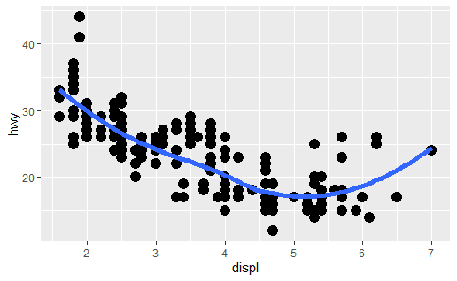

```r
ggplot() +
  geom_point(data = mpg, mapping = aes(x = displ, y = hwy),size=4) +
  geom_smooth(data = mpg, mapping = aes(x = displ, y = hwy),se=FALSE, size=2)
```

2: upper right.

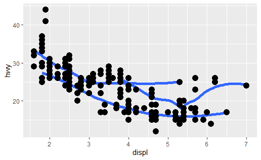

```r
ggplot() +
    geom_smooth(data = mpg, mapping = aes(x = displ, y = hwy,group=drv),se=FALSE, size=2) +
  geom_point(data = mpg, mapping = aes(x = displ, y = hwy),size=4)
```

3: middle left.

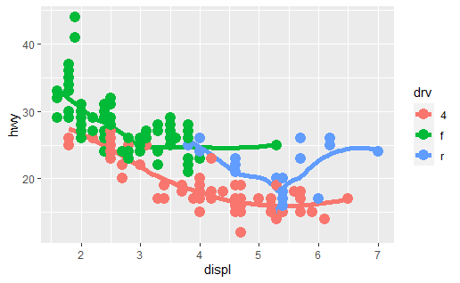

```r
ggplot() +
    geom_smooth(data = mpg, mapping = aes(x = displ, y = hwy,color=drv),se=FALSE, size=2) +
  geom_point(data = mpg, mapping = aes(x = displ, y = hwy,color=drv),size=4)
```

4: middle right.

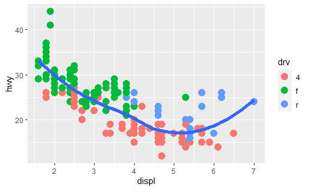

```r
ggplot() +
    geom_point(data = mpg, mapping = aes(x = displ, y = hwy,color=drv),size=4)+
    geom_smooth(data = mpg, mapping = aes(x = displ, y = hwy),se=FALSE, size=2)
```

5: lower left.

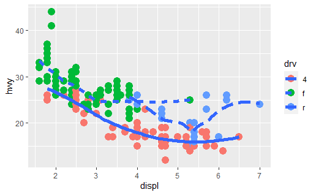

```r
ggplot() +
    geom_point(data = mpg, mapping = aes(x = displ, y = hwy,color=drv),size=4) +
    geom_smooth(data = mpg, mapping = aes(x = displ, y = hwy,linetype=drv),se=FALSE, size=2)
```

6: lower right. *Hint:* Read the help file for `geom_point`. Use `shape = 21`, `stroke = 2`, and `size = 3`.

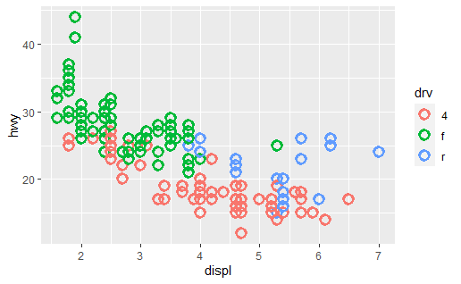

```r
ggplot()+
  geom_point(data = mpg, mapping = aes(x = displ, y = hwy,color=drv),shape=21,size=3,stroke=2)
```